# James’ manual

### 3.8.4 Step 4: customizing your figure

The figure below equals the figure above, after the following modifications.

1. Remove the first region (Groningen)
   - the figure below does not show Groningen anymore
2. Remove the value of region Friesland
   - the figure still shows the region even though its color is transparent now
3. The label of the region Friesland was updated to ‘(leeg)’
4. The `palette` holds one color more (+rose)
5. Add parameter `geo_col_threshold` with values for the colors in the palette (1 = anakiwa, 18.5 = endeavour, 36 = rose); Section ‘Colors’ explains the use of colors in detail
6. Add parameters `name` and `name_col` to specify the legend; Section ‘Legend’ explains in detail how you can further tweak or remove the legend
7. Finally add a `footnote` and a `title`

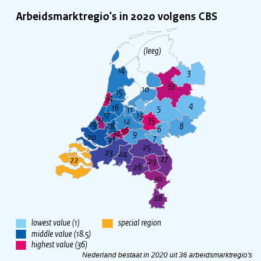

**Relevant parameters:**

| style | map |
| --- | --- |
| title | Arbeidsmarktregio’s in 2020 volgens CBS |
| footnote | Nederland bestaat in 2020 uit 36 arbeidsmarktregio’s |
| name_col | special region = sun |
| geo_cbs_map | arbeidsmarktregio_2020 |
| name | lowest value (1);; middle value (18.5);; highest value (36);; special region |
| geo_col_threshold | 1, 18.5, 36 |
| palette | anakiwa, endeavour, rose |

**How to reproduce this figure:** copy this xlsx-file and this batch file to a personal directory and start the batch file. You can also run this R-script in R.

### 3.8.5 Parameters to further tweak your map

The Netherlands is divided in several ways in different regions. You can use these parameters to choose which devision you want to use. You may add items to the legend with parameter `name`. The items in the legend will be colored in the same order as the colors in your `palette`. See also parameter(s): name, palette.

- **`geo_border_col`**: not documented yet. The value is of type ‘string’. Example(s): `black`. For the *default* style the value is `gray`.
- **`geo_border_lwd`**: not documented yet. The value is of type ‘numeric’. Example(s): `1`. For the *default* style the value is `0.5`.
- **`geo_cbs_map`**: this parameter specifies a specific division of The Netherlands in regions. See appendix of manual for the full list of options currently available. The value is of type ‘string’. Example(s): `arbeidsmarktregio_2018`. Figure(s) using ‘geo_cbs_map’: geo-first-example, Arbeidsmarktregio’s in 2020 volgens CBS.
- **`geo_col_threshold`**: the order of the values of this parameter correspond to the order of the colors in your palette. Regions with the first (second, third, etc.) value will get the first (second, third, etc.) color from your palette. Regions with other values will be be colored by linear interpolation of the colors in your palette. Regions with values outside the range of this parameter will get the figure’s background color. The values in this parameter must be stricktly increasing. The value is a list with elements of the type ‘numeric’ separated by ‘,’. Example(s): `0, 100`. See also parameter(s): palette, palette_blue. Figure(s) using ‘geo_col_threshold’: Arbeidsmarktregio’s in 2020 volgens CBS.
- **`region_label_col`**: not documented yet. The value is of type ‘string’. Example(s): `white`. For the *default* style the value is `black`.
- **`region_label_font_size`**: relative font size. The value is of type ‘numeric’. Example(s): `0.7, 1.5`. For the *default* style the value is `1`.
- **`region_label_font_style`**: 1 = normal, 2 = bold, 3 = italic, 4 = bold and italic. The value is of type ‘numeric’. Example(s): `1, 2, 3, 4`. For the *default* style the value is `3`.

# 4 Styles: layout, size, dimensions, orientation and language

James has a parameter `style`, which enables you to quickly change the layout of your figure. Each style defines a unique combination of settings.

The main styles are:

## 4.1 Dimensions styles

The default dimensions of a figure are width `7.5 cm` by height `7.5 cm`. You can change this by setting the `style` parameter with one of the following values. James will automatically adjust all internal figure margins accordingly.

- `style = small` for a slightly smaller figure. This is the standard for figures in a so-called ‘frame’ (Dutch: ‘kader’).
  - `width`: 6.8 cm, `height`: 6.8 cm
- `style = big` for figures with a lot of information (*e.g.* a barplot with many bars and labels on top of them).
  - `width`: 15 cm, `height`: 15 cm
- `style = tall` for figures that need extra vertical space in your text document.
  - `height`: 15.5 cm
- `style = slide` to fit the dimensions of a PowerPoint slide that has two figures on it.
  - `width`: 14.2 cm, `height`: 11.7 cm
- `style = slide-wide` to fit as a landscape image on a PowerPoint slide.
  - `width`: 21 cm, `height`: 11.7 cm, `margin_south`: 2.8 cm
- `style = wide` for figures that need extra horizontal space in a text document.
  - `width`: 15.5 cm

It does not make sense to combine these.

## 4.2 Document styles

Currently there are two document styles: the default one that is used for a *notition*, a *memo* and a *background document*, and the *kansrijk* document style.

- `style = kansrijk` the `kansrijk` style removes the title, has different dimensions and different colors.
  - `style`: no-title, `width`: 12.5 cm, `height`: 7 cm, `bg_col`: #ffffff, `palette`: kansrijk

## 4.3 Language style

- `style = english` if you want numbers to have a dot (.) as decimal separator and a comma (,) for thousands separator. If you use the cpb logo (`logo_show = y`, explained elsewhere), this style will make sure that the text next to the logo is in English too.
  - `decimal_mark`: ., `big_mark`: ,, `legend_forecast_text`: prognosis, `forecast_text`: prognosis

This style combines always with other styles.

## 4.5 Axes styles

- `style = x-top` the `x-top` style creates extra space for an axis at the top of your figure.
  - `title_align`: right, `y_title_align`: right, `margin_north_extra`: 0.2 cm
- `style = y-right` the `y-right` style creates extra space for a secondary y-axis at the right of your plot.
  - ``: (to do)

## 4.6 Figure type styles

- `style = fan` sets colors and types for standard fans with one line, followed by three bandwidths.
  - `type`: line, area, area, area, area, area, area, `legend_n_per_column`: 4, `palette`: fan
- `style = box-plot` for box-plots.
  - `style`: no-legend, `y_title_v_shift`: 0.3 cm, `box_gap_fraction`: 0.5, `box_median_lab_show`: y, `margin_north`: 0.95 cm
- `style = map` if you want to make a map with regions, you can use the `map` style.
  - `legend_y`: 1.08 cm, `margin_south`: 1.5 cm, `margin_west`: 0.5 cm, `margin_north`: 0.8 cm, `margin_east`: 0.5 cm, `palette`: palette_map

Of course, you can combine some styles (not all, because some contradict each other, *e.g.* the dimensions). The following figure combines `style = no-title, no-legend`. Some styles are automatically combined with others. For example, `box` implements `no-legend` and `kansrijk` implements `no-title`.

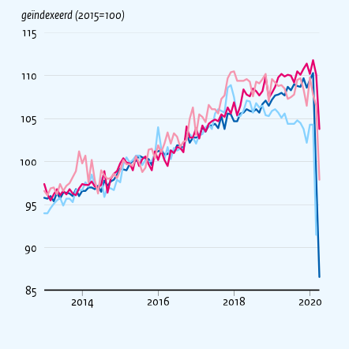

**Relevant parameters:**

| style | no-title, no-legend |
| --- | --- |
| title | Industriële productie en detailhandel |
| y_title | geïndexeerd (2015=100) |
| x_lim_follow_data | y |

**How to reproduce this figure:** copy this xlsx-file and this batch file to a personal directory and start the batch file. You can also run this R-script in R.

In the above case James will give you a trivial warning:

```r
## WARNING ## While your style includes 'no-title', you have specified a title. This seems contradictionary.
```

For the record also parameter `style = default`: the `default` style you get for free. You don’t have to specify it. It is put as last by default, hence other styles will have priority over it..

## 4.7 Set dimensions to a custom value

- **`empty_fraction_plot`**: minimal fraction of plot area between outer gridlines and graph. In practice, at least half of this fraction is free above (and below) the graph. [As of 2020-10-14 this functionality is disabled] The value is of type ‘numeric’. Example(s): `0.3`. For the *default* style the value is `0`.
- **`height`**: height of the resulting image. The value is of type ‘numeric’. Unit: ‘cm’. For the *default* style the value is `7.5`. For the *small* style the value is `6.8`. For the *kansrijk* style the value is `7`. For the *big* style the value is `15`. For the *slide* style the value is `11.7`. For the *slide-wide* style the value is `11.7`. For the *tall* style the value is `15.5`.
- **`labels_margin_left`**: margin left of title, y_title, y_lab. Same margin is used at right side of main title if it is automatically rescaled if it grows to wide. The value is of type ‘numeric’. Unit: ‘cm’. For the *default* style the value is `0.45`.
- **`labels_margin_right`**: margin right of x_title. The value is of type ‘numeric’. Unit: ‘cm’. For the *default* style the value is `0.45`.
- **`margin_east`**: margin right of plotting area. The value is of type ‘numeric’. Unit: ‘cm’. For the *default* style the value is `0.63500000000000001`. For the *map* style the value is `0.5`.
- **`margin_east_extra`**: extra margin for right y-axis. The value is of type ‘numeric’. Unit: ‘cm’.
- **`margin_north`**: margin above plotting area. The value is of type ‘numeric’. Unit: ‘cm’. Example(s): `1.524`. For the *default* style the value is `1.3`. For the *box-plot* style the value is `0.95`. For the *map* style the value is `0.8`. For the *no-title* style the value is `0.7`.
- **`margin_north_extra`**: not documented yet. The value is of type ‘numeric’. Unit: ‘cm’. For the *default* style the value is `0`. For the *x-top* style the value is `0.2`.
- **`margin_south`**: margin below plotting area. The value is of type ‘numeric’. Unit: ‘cm’. Example(s): `1.905`. For the *default* style the value is `2.2999999999999998`. For the *slide-wide* style the value is `2.8`. For the *map* style the value is `1.5`. For the *no-legend* style the value is `1.25`. For the *interactive* style the value is `3`.
- **`margin_west`**: set automatically for most styles. Sum of maximum width of your labels, plus margin_west_delta. The value is of type ‘numeric’. Unit: ‘cm’. For the *map* style the value is `0.5`.
- **`margin_west_delta`**: this is added to margin_west. margin_west is dynamically calculated based on actual width of your `y_lab`‘s, the `labels_margin_left` and `y_lab_margin_right`. This is to guarantee identical alignment of all your labels at the left side of the plot. The value is of type ’numeric’. Unit: ‘fraction of width’. For the *default* style the value is `0`. For the *interactive* style the value is `-0.04`.
- **`width`**: width of the resulting image. The value is of type ‘numeric’. Unit: ‘cm’. For the *default* style the value is `7.5`. For the *small* style the value is `6.8`. For the *kansrijk* style the value is `12.5`. For the *big* style the value is `15`. For the *slide* style the value is `14.2`. For the *slide-wide* style the value is `21`. For the *wide* style the value is `15.5`.
- **`y_lab_margin_right`**: margin between y_lab and plotting area. The value is of type ‘numeric’. Unit: ‘fraction of width’. For the *default* style the value is `1.4999999999999999E-2`.

## 4.8 Portrait or landscape, vertical or horizontal figures

Parameter `turn` with value `turn = y` (or `turn = TRUE`) swaps the *x*- and *y*-axes of your plot:

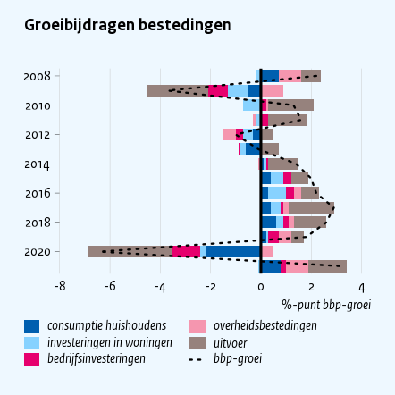

**Relevant parameters:**

| type | bar=, bar=, bar=, bar=, bar=, line |
| --- | --- |
| title | Groeibijdragen bestedingen |
| y_title | %-punt bbp-groei |
| turn | y |
| name_col | bbp-groei=black |
| line_lty | 3 |

**How to reproduce this figure:** copy this xlsx-file and this batch file to a personal directory and start the batch file. You can also run this R-script in R.

## 4.9 An example of a ‘kansrijk’ figure

Kansrijk figures don’t have a title, are wider, have a white background and use a different color palette for the time series.

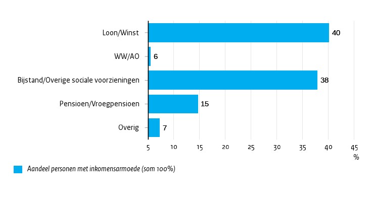

**Relevant parameters:**

| [style](https://dont-remove-this) | kansrijk, no-title |
| --- | --- |
| [type](https://dont-remove-this) | bar– |
| [y_title](https://dont-remove-this) | % |
| [scale](https://dont-remove-this) | 100 |
| [turn](https://dont-remove-this) | y |
| [bar_lab_show](https://dont-remove-this) | y |

**How to reproduce this figure:** copy this xlsx-file and this batch file to a personal directory and start the batch file. You can also run this R-script in R.

This manual contains a section specifically on bar-plots that explains in detail how you can create your own custom bar-plot.

## 4.10 Add the CPB-logo to your figure

For official figures, you may want to add a logo on top. Parameter `logo_show``= y` does so.

[figure not shown]

**Relevant parameters:**

| type | bar–, line |
| --- | --- |
| title | Economische groei in Nederland |
| y_title | mutatie in % |
| logo_show | y |
| x_lab_date_show | y |
| x_ticks_date | years, quarters |
| y_axis | l, r |
| y_right_title | € miljard |

**How to reproduce this figure:** copy this xlsx-file and this batch file to a personal directory and start the batch file. You can also run this R-script in R.

- **`logo`**: this function first scales your data (if p$scale != 1), then it removes data outside user p$x_lim, p$y_lim. It puts x-values in p$x and y-values in p$y. The value is of type ‘file’. For the *default* style the value is `ext/img/rijkslogo.png`.
- **`logo_height`**: not documented yet. The value is of type ‘numeric’. Unit: ‘cm’. For the *default* style the value is `1`.
- **`logo_show`**: not documented yet. The value is of type ‘bool’. For the *default* style the value is `n`. Figure(s) using ‘logo_show’: Economische groei in Nederland.
- **`logo_text_en`**: not documented yet. The value is of type ‘string’. For the *default* style the value is `CPB Netherlands Bureau for\nEconomic Policy Analysis`.
- **`logo_text_nl`**: not documented yet. The value is of type ‘string’. For the *default* style the value is `Centraal Planbureau`.

# 5 The basics

This Section discusses the basics which probably enable you to create most of the figures. This Section ends with Subsection structure of the xlsx-file, which explains which files are and which files aren’t processed by James. It also explains the details you need if you start creating your own xlsx files. Next, Section Quick customizations explains how to further tailor your figures in more detail.

## 5.1 Frequently used settings

Use `open = y` (or `n`) if you (don’t) want your figures to be opened automatically after creation. To speed-up the process, you can temporarily exclude some figures from the generation process by `create = n`.

## 5.2 Forecasts, prognoses, predictions

Time series often have a known part (usually in the past) and a predicted part (*e.g.* in the future). You can use parameter `forecast_x` to indicate from which point on your data is predicted. Parameter `forecast_x` is defined as the last moment (read: *x*-value) that is observed/known. Values larger than `forecast_x` are considered to be forecasted.

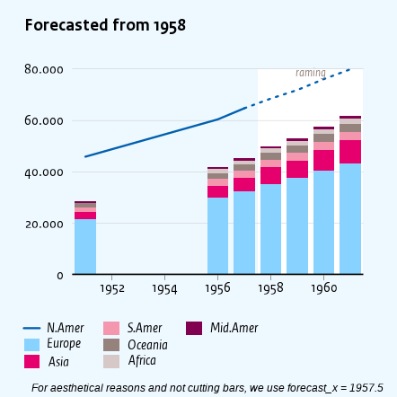

**Relevant parameters:**

| type | line, bar=, bar=, bar=, bar=, bar=, bar= |
| --- | --- |
| forecast_x | 1957.5 |
| title | Forecasted from 1958 |
| footnote | For aesthetical reasons and not cutting bars, we use forecast_x = 1957.5 |
| tab | NA |

**How to reproduce this figure:** copy this xlsx-file and this batch file to a personal directory and start the batch file. You can also run this R-script in R.

### 5.2.1 Parameters to tweak your forecast layout

- **`forecast_below_gridline`**: text above or below upper gridline. The value is of type ‘bool’. For the *default* style the value is `y`.
- **`forecast_bg_col`**: background color for forecasting. The value is of type ‘string’. For the *default* style the value is `#ffffff`.
- **`forecast_bg_show`**: show background color behind forecasted part of series. The value is of type ‘bool’. For the *default* style the value is `y`.
- **`forecast_col_transparency`**: forecasted areas/bars have this transparency level. Zero means no transparancy, one means full transparancy. PLEASE REMOVE THIS PARAMETER. NO LONGER USED. WE NOW ‘shade’ BARS/AREAS The value is of type ‘numeric’. Unit: ‘fraction (0..1]’. Example(s): `0.3, 0.5, 0.7`. For the *default* style the value is `0`.
- **`forecast_font_size`**: size of forecast_text. The value is of type ‘numeric’. For the *default* style the value is `0.9`.
- **`forecast_font_style`**: 1 = normal, 2 = bold, 3 = italic, 4 = bold and italic. The value is of type ‘numeric’. Example(s): `1, 2, 3, 4`. For the *default* style the value is `3`.
- **`forecast_shading_angle`**: slope of shading lines, given as an angle (counter-clockwise). The value is of type ‘numeric’. Unit: ‘degrees’. Example(s): `0, 45, 90, 135`. For the *default* style the value is `45`.
- **`forecast_shading_col`**: color of forecast shading. Default color is background color of the figure. The value is of type ‘string’. For the *default* style the value is `bg_col`.
- **`forecast_shading_col_transparency`**: transparency of shading. The value is of type ‘numeric’. Unit: ‘fraction (0..1]’. Example(s): `0.3, 0.5, 0.65`. For the *default* style the value is `0.65`.
- **`forecast_shading_density`**: density of shading of areas and bars that are forecasted. The value is of type ‘numeric’. Unit: ‘cm^-1’. Example(s): `5, 10, 20`. For the *default* style the value is `10`.
- **`forecast_shading_show`**: by default shading is added to forecasted bars/areas. The value is of type ‘bool’. For the *default* style the value is `n`.
- **`forecast_text`**: text that marks the start of the forecast. The value is of type ‘string’. For the *default* style the value is `raming`. For the *english* style the value is `prognosis`.
- **`forecast_text_col`**: color of the forecast_text. The value is of type ‘string’. For the *default* style the value is `brown`.
- **`forecast_text_show`**: add text at top of plot (or right side for turned plots) to mark start of forecast. The value is of type ‘bool’. For the *default* style the value is `y`.
- **`forecast_x`**: the x-value (usually a date) that separates observed values from predicted values. The value is of type ‘numeric’.
- **`line_obs_fc_lty`**: line types of observed respectively forecasted data. Please use the default settings. The value is a list with elements of the type ‘numeric’ separated by ‘,’. For the *default* style the value is `1, 3`. See also parameter(s): line_lty.

## 5.3 Add help lines and shading

- **`grid_lines_col`**: not documented yet. The value is of type ‘string’. For the *default* style the value is `gray`.
- **`grid_lines_lwd`**: line width. The value is of type ‘numeric’. For the *default* style the value is `0.25`.
- **`hline_bold`**: by default the lowest gridline is bold. Except if your plot contains bars and zero is visible, then the default is zero. If you want the bold line(s) to appear at other places, you can specify the(ir) y-value(s) here. The value is of type ‘numeric’. See also parameter(s): hline_bold_show. Figure(s) using ‘hline_bold’: Oversterfte in 2020, VWO, VWO, Koopkrachtontwikkeling, Koopkrachtontwikkeling, trend-vs-niveau.
- **`hline_bold_col`**: line color. The value is of type ‘string’. For the *default* style the value is `black`.
- **`hline_bold_lwd`**: line width. The value is of type ‘numeric’. For the *default* style the value is `2`.
- **`hline_bold_show`**: switch off the horizontal bold line if you don’t want it. The value is of type ‘bool’. For the *default* style the value is `y`.
- **`hline_dash`**: not documented yet. The value is of type ‘numeric’. Figure(s) using ‘hline_dash’: Kans om in risicogroep te zitten.
- **`hline_dash_col`**: not documented yet. The value is of type ‘string’. For the *default* style the value is `black`.
- **`hline_dash_lty`**: not documented yet. The value is of type ‘numeric’. For the *default* style the value is `3`.
- **`hline_dash_lwd`**: not documented yet. The value is of type ‘numeric’. For the *default* style the value is `1`.
- **`shading_suppress_col`**: not documented yet. The value is of type ‘string’. For the *default* style the value is `#FFFFFF44`.
- **`shading_suppress_x`**: same as shading_x, except that it is ran after most plotting is done so you can suppress parts of plot. The value is a list with elements of the type ‘numeric’ separated by ‘,’.
- **`vline_bold`**: to be implemented The value is of type ‘numeric’.
- **`vline_dash`**: not documented yet. The value is a list with elements of the type ‘numeric’ separated by ‘,’. Figure(s) using ‘vline_dash’: Oversterfte in 2020, Impact no-deal Brexit (horizontal), Impact no-deal Brexit (tall).
- **`vline_dash_col`**: not documented yet. The value is of type ‘string’. For the *default* style the value is `black`. Figure(s) using ‘vline_dash_col’: Oversterfte in 2020.
- **`vline_dash_date`**: not documented yet. The value is a list with elements of the type ‘Date’ separated by ‘,’. Example(s): `43861`. Figure(s) using ‘vline_dash_date’: Rentespreads op overheidsschuld.
- **`vline_dash_lty`**: not documented yet. The value is of type ‘numeric’. For the *default* style the value is `3`.
- **`vline_dash_lwd`**: not documented yet. The value is of type ‘numeric’. For the *default* style the value is `1`.
- **`x_shading`**: vertical shading (from, to, from, to, etc.). The value is a list with elements of the type ‘numeric’ separated by ‘,’. Example(s): `2000, 2005, 2010, 2015`.
- **`x_shading_col`**: not documented yet. The value is of type ‘string’. For the *default* style the value is `#00000022`.

## 5.4 Plot a formula

There are two ways to visualize a formula. First, you can use formula’s in Excel (see Section Data manipulation for details). Second, with the parameter `formula`.

The following figure adds the sinus of the *x*-values in the example from Section A kick-start example, multiplied by ten. Please note that the first column in the `data` parmeter (*i.e.* `p$data[, 1]`), holds the *x*-values. The following column in the `data` parameter (*i.e.* `p$data[, 2]`) holds the first time series (here: `(6 - x)^2`), the third column (*i.e.* `p$data[, 3]`) holds the second time series, and so on.

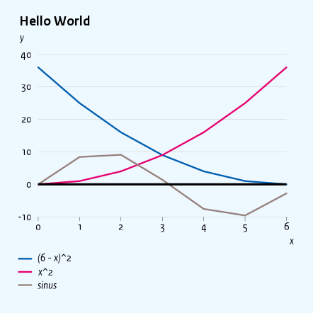

**Relevant parameters:**

| title | Hello World |
| --- | --- |
| x_title | x |
| y_title | y |
| hline_bold | 0 |
| formula | 10 * sin(p$data[, 1]) |
| formula_name | sinus |

**How to reproduce this figure:** copy this xlsx-file and this batch file to a personal directory and start the batch file. You can also run this R-script in R.

### 5.4.1 Tailor your formula

- **`formula`**: append outcome of formula after last column to data. Please note, your data x-values are in p$data[, 1]. The first series’ values are in p$data[, 2], the second in p$data[, 3] and so on. So, the example determines the mean of the first and second series. The value is of type ‘string’. Example(s): `rowMeans(p$data[, 2:3])`.
- **`formula_name`**: legend name of formula. The value is of type ‘string’. Example(s): `sinus`.

## 5.5 Add custom R-code for plotting

- **`custom`**: custom R-code that will be run after the rest of the plotting. Your meta data are available as in your data sheets. For example meta$data[, 1] are the x-values, meta$data[, 2] is your first series, etc. If you generate figures from R (not Excel), you may define a function ‘custom <- function(meta) { … }’ with a custom implementation instead. The value is of type ‘string’. Example(s): `lines(meta$data[, 1], mean(meta$data[, 2:3]))`.

## 5.6 File format (gif, jpg, pdf, png, svg)

You can just add the formats you want as boolean parameters to your `meta` tab. By default `png = y` and other formats are put to `n` by default.

Examples:

- `gif = y` provides an animated figure with data starting at zero and ‘growing’ in `gif_n_frames` frames (default 20) to their actual values. You can set the delay between the steps with paramter `gif_delay` (default 0.1 seconds). This setting is described in more detail further on. NB This setting may work but is not regularly checked and not supported.
- `jpg = y` provides a jpeg file. This is a compressed file, which may be used to save disk space. The image quality can be controled by `quality` (default 75). *NB This setting may work but is not regularly checked and not supported.*
- **`pdf = y`** provides a vector graphics version of your figure (*i.e.* ‘infinite’ resolution), which may be used in LaTeX or pdf documents.
- **`png = y`** (the default) provides a so-called ‘portable network graphics’ version of your figure. **This setting is recommended** because png’s are not compressed (and are hence less blurry than jpg’s) and guarantee that their layout (including font) is invariant between different software programs that show them (*e.g.* Word, pdf, PowerPoint, etc.).
- `svg = y` provides a scalable vector graphics version of your figure, which may be used on *e.g.* websites. Svg is also vector graphics but not displayed in each word processing program. NB This setting may work but is not regularly checked and not supported.

So, we recommend using the default **`png`** unless you have good reasons to use a different format.

### 5.6.1 A gif is an animated image

[figure not shown]

Please contact the author if you want to gifify your figure :-)

## 5.7 Title

Obviously, you can set the title of your figure with the parameter `title`. If your title is too broad for your figure, you may add a newline with `\n` to your title. If your figure is (still) too broad, James will autoscale it smaller to make it fit the margins. Please beware, if this happens, your plot doesn’t comply anymore with the CPB-style.

Please note: the newline character `n` is not implemented for each text label parameter, but it’s worth trying.

## 5.8 Footnote

You may add extra information, *e.g.* the source, to the figure by inserting a footnote. By default, the footnote is italic black, aligned bottom right. The following figure shows a footnote that is more prominent but visually less attractive.

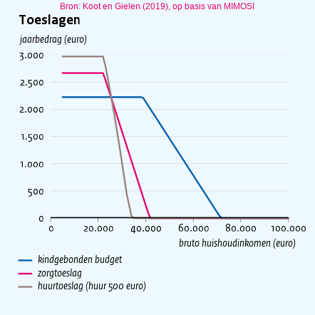

**Relevant parameters:**

| title | Toeslagen |
| --- | --- |
| x_title | bruto huishoudinkomen (euro) |
| y_title | jaarbedrag (euro) |
| footnote | Bron: Koot en Gielen (2019), op basis van MIMOSI |
| footnote_col | rose |
| footnote_side | top |
| footnote_align | center |
| footnote_font_style | 1 |
| x_lab_big_mark_show | y |

**How to reproduce this figure:** copy this xlsx-file and this batch file to a personal directory and start the batch file. You can also run this R-script in R.

A footnote may refer to a text label (*e.g.* title) in your figure. In that case, you may want to use a ¹, ², ³, or * in both the text label and the footnote.

- **`footnote`**: footnote, placed at bottom of figure, aligned right by default. The value is of type ‘string’. Example(s): `¹this is a footnote`. Figure(s) using ‘footnote’: Six different line types, Oversterfte in 2020, Bestaande koopwoningen, Bestaande koopwoningen, Investeringen in Nederland¹ door de zwaarst-eurolanden in 2018 en vice versa, Arbeidsmarktregio’s in 2020 volgens CBS, Verlies van banken na afschrijving 20% van devan GIIPS-landen, Toeslagen, VMBO.
- **`footnote_align`**: to which side you want to align your footnote horizontally. The value is of type ‘string’. Example(s): `left, center, right`. For the *default* style the value is `right`. Figure(s) using ‘footnote_align’: Toeslagen.
- **`footnote_col`**: not documented yet. The value is of type ‘string’. For the *default* style the value is `black`. Figure(s) using ‘footnote_col’: Six different line types, Toeslagen, VMBO.
- **`footnote_font_size`**: size of footnote text. The value is of type ‘numeric’. For the *default* style the value is `0.85`.
- **`footnote_font_style`**: 1 = normal, 2 = bold, 3 = italic, 4 = bold and italic. The value is of type ‘numeric’. Example(s): `1, 2, 3, 4`. For the *default* style the value is `3`. Figure(s) using ‘footnote_font_style’: Toeslagen.
- **`footnote_side`**: to which side you want to align your footnote vertically. The value is of type ‘string’. Example(s): `bottom, top`. For the *default* style the value is `bottom`. Figure(s) using ‘footnote_side’: Toeslagen.
- **`footnote_x`**: distance from left/right side of figure. The value is of type ‘numeric’. Unit: ‘cm’. For the *default* style the value is `0.25`.
- **`footnote_y`**: distance from bottom/top of figure. The value is of type ‘numeric’. Unit: ‘cm’. For the *default* style the value is `0.15`.

## 5.9 Text label

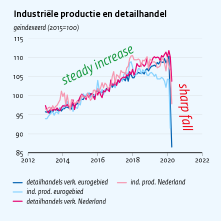

**Relevant parameters:**

| title | Industriële productie en detailhandel |
| --- | --- |
| y_title | geïndexeerd (2015=100) |
| text_x | 2016, 2021 |
| text_y | 108, 97 |
| text_label | steady increase;; sharp fall |
| text_rotation | 25, -85 |
| text_col | green, red |
| text_font_size | 2 |

**How to reproduce this figure:** copy this xlsx-file and this batch file to a personal directory and start the batch file. You can also run this R-script in R.

If your *x*-axis comprises dates, you should use `text_x_date` instead of `text_x` as in the following figure. Please see the subsection on parameters for datails.

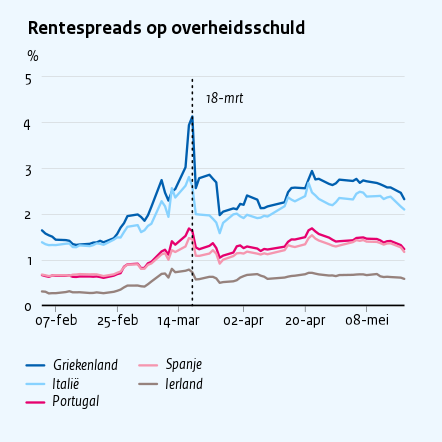

**Relevant parameters:**

| title | Rentespreads op overheidsschuld |
| --- | --- |
| y_title | % |
| x_lim | 2020.09, 2020.38 |
| vline_dash_date | 2020-03-18 |
| text_x_date | 2020-03-18 |
| text_y | 4.5 |
| text_pos | 4 |
| text_label | 18-mrt |

**How to reproduce this figure:** copy this xlsx-file and this batch file to a personal directory and start the batch file. You can also run this R-script in R.

### 5.9.1 Parameters to tweak your text label

- **`text_col`**: the color of the label. The value is a list with elements of the type ‘string’ separated by ‘,’. Example(s): `black, rose, green`. For the *default* style the value is `black`. Figure(s) using ‘text_col’: Oversterfte in 2020, Industriële productie en detailhandel, Impact no-deal Brexit (horizontal), Impact no-deal Brexit (tall).
- **`text_font_size`**: relative font size. The value is a list with elements of the type ‘numeric’ separated by ‘,’. Example(s): `0.7, 1.5`. For the *default* style the value is `1`. Figure(s) using ‘text_font_size’: Industriële productie en detailhandel.
- **`text_font_style`**: 1 = normal, 2 = bold, 3 = italic, 4 = bold and italic. The value is a list with elements of the type ‘numeric’ separated by ‘,’. Example(s): `1, 2, 3, 4`. For the *default* style the value is `3`.
- **`text_label`**: the text label you want to show in the figure. The value is a list with elements of the type ‘string’ separated by ‘;;’. Example(s): `first label;; second label`. Figure(s) using ‘text_label’: Oversterfte in 2020, Industriële productie en detailhandel, Rentespreads op overheidsschuld, Impact no-deal Brexit (horizontal), Impact no-deal Brexit (tall).
- **`text_offset`**: distance (‘offset’) of the text label from the specified coordinate in fractions of the width of the letter ‘m’. The value is a list with elements of the type ‘numeric’ separated by ‘,’. For the *default* style the value is `0.5`. Figure(s) using ‘text_offset’: Different alignment for PT.
- **`text_pos`**: alignment of your text label. Leave empty if you want your text centerd on the given (x,y) coordinates. Or: 1 = below, 2 = left, 3 = above, 4 = right. The value is a list with elements of the type ‘numeric’ separated by ‘,’. Example(s): `1, 2, 3, 4`. Figure(s) using ‘text_pos’: Oversterfte in 2020, Rentespreads op overheidsschuld.
- **`text_rotation`**: the rotation of the label in degrees counterclockwise. Zero (0) means horizontal, 90 means vertical. The value is a list with elements of the type ‘numeric’ separated by ‘,’. Example(s): `0, 45, 90`. For the *default* style the value is `0`. Figure(s) using ‘text_rotation’: Industriële productie en detailhandel, Impact no-deal Brexit (horizontal).
- **`text_x`**: the x-position of your text label. If your x-axis is numeric, just put the value here. If you use bars, then text_x works as follows. The x-value of the first x-position is 1, *i.e.* where the first (set of) bars are located. The second is 2, etc. So, if you want your label inbetween the first two x-position, you should use 1.5 as a value. If your x-axis holds dates, please use text_x_date instead. The value is a list with elements of the type ‘numeric’ separated by ‘,’. Figure(s) using ‘text_x’: Oversterfte in 2020, Industriële productie en detailhandel, Impact no-deal Brexit (horizontal), Impact no-deal Brexit (tall).
- **`text_x_date`**: if your x-axis consists of dates, you should use this parameter instead of text_x, to indicate what the x-postion of your text label is. Please mark the cell in Excel as a ‘date’ (*i.e.* not as a regular number). The value is a list with elements of the type ‘Date’ separated by ‘,’. Example(s): `2020-03-18`. Figure(s) using ‘text_x_date’: Rentespreads op overheidsschuld.
- **`text_y`**: the y-postion of your text label. The value is a list with elements of the type ‘numeric’ separated by ‘,’. Figure(s) using ‘text_y’: Oversterfte in 2020, Industriële productie en detailhandel, Rentespreads op overheidsschuld, Impact no-deal Brexit (horizontal), Impact no-deal Brexit (tall).

## 5.10 Text labels as ‘time series’

TODO HIER ANDERE VARS TOEVOEGEN VOOR MEER CONTROLE

- **`label`**: not documented yet. The value is a list with elements of the type ‘string’ separated by ‘;;’.
- **`label_align`**: 0: alignment at given coordinates, 1: below, 2: left, 3: above, 4: right. The value is a list with elements of the type ‘numeric’ separated by ‘,’. Example(s): `1, 2, 3, 4`. For the *default* style the value is `4`.
- **`label_font_size`**: relative to font size of title. The value is a list with elements of the type ‘numeric’ separated by ‘,’. For the *default* style the value is `1`. Figure(s) using ‘label_font_size’: Overlapping labels (NL, PT), Different alignment for PT.
- **`label_offset`**: distance (‘offset’) of the text label from the specified coordinate in fractions of the width of the letter ‘m’. The value is a list with elements of the type ‘numeric’ separated by ‘,’. For the *default* style the value is `0.5`.
- **`label_series_n`**: the number of the time series that you want to label. The value is of type ‘numeric’. For the *default* style the value is `1`.

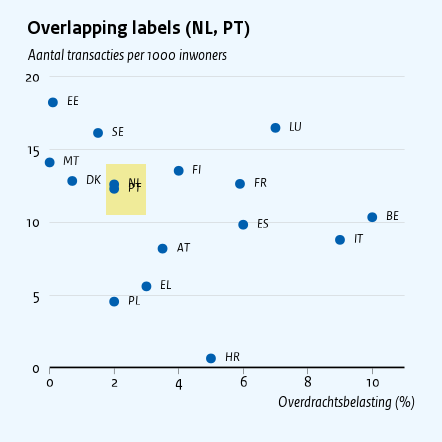

**Relevant parameters:**

| style | no-legend |
| --- | --- |
| type | dot, param |
| title | Overlapping labels (NL, PT) |
| x_title | Overdrachtsbelasting (%) |
| y_title | Aantal transacties per 1000 inwoners |
| x_lim | 0, 11 |
| dot_size | 0.8 |
| label_font_size | 0.9 |
| rect_xleft | 1.75 |
| rect_ybottom | 10.5 |
| rect_xright | 3 |
| rect_ytop | 14 |
| rect_col | yellow |

**How to reproduce this figure:** copy this xlsx-file and this batch file to a personal directory and start the batch file. You can also run this R-script in R.

The following figure fixes the overlap by adding parameter `label_align` to the data tab and sets a specific value of 1 (meaning: align below) to label PT. In addition the space between the labels and the dots is reduced with `text_offset = 0.25`.

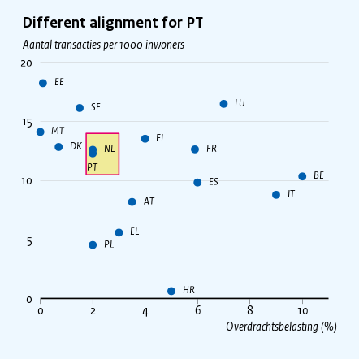

**Relevant parameters:**

| style | no-legend |
| --- | --- |
| type | dot, param, param |
| title | Different alignment for PT |
| x_title | Overdrachtsbelasting (%) |
| y_title | Aantal transacties per 1000 inwoners |
| x_lim | 0, 11 |
| dot_size | 0.8 |
| label_font_size | 0.9 |
| text_offset | 0.25 |
| rect_xleft | 1.75 |
| rect_ybottom | 10.5 |
| rect_xright | 3 |
| rect_ytop | 14 |
| rect_col | yellow |
| rect_border | rose |

**How to reproduce this figure:** copy this xlsx-file and this batch file to a personal directory and start the batch file. You can also run this R-script in R.

Section The data tabs explains in detail how and when to use the data tab to set or create parameters that can be used in the plotting.

## 5.11 Axes

This section explains how to tweak your axes. It starts with a figure that uses parameters `x_axis_show` and `y_axis_show` to hide both axes.

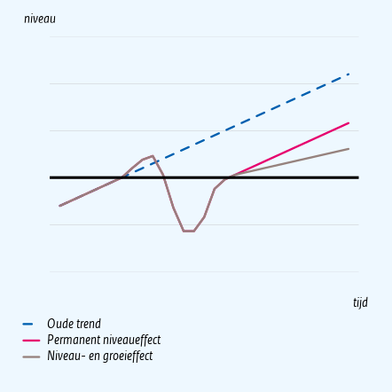

**Relevant parameters:**

| style | no-title |
| --- | --- |
| x_title | tijd |
| y_title | niveau |
| line_lty | 2, 1, 1 |
| hline_bold | 100 |
| x_axis_show | n |
| y_axis_show | n |

**How to reproduce this figure:** copy this xlsx-file and this batch file to a personal directory and start the batch file. You can also run this R-script in R.

Please note that the figure above uses long dashes (`line_lty``= 2`), while the adviced default is short dashes (`line_lty``= 3`).

To do: Text on the numbers, dates, precision, ook dec separator, x_lim_follow_data

### 5.11.1 Parameters to tweak axes, gridlines and ticks

It is easy to adapt the layout of the axes (decimal separerator, etc.) when switching between languages with `style = english` (default style is Dutch). See also parameter(s): style.

- **`big_mark`**: big mark is put beween every 3 decimals before the decimal separator. The value is of type ‘string’. Example(s): `. or ,`. For the *default* style the value is `.`. For the *english* style the value is `,`.
- **`decimal_mark`**: decimal separator. The value is of type ‘string’. Example(s): `. or ,`. For the *default* style the value is `,`. For the *english* style the value is `.`.
- **`force_y_at`**: normally James adds whitespace around the graph (see parameter empty_fraction_plot). You can force James to put the gridlines at precisely y_at (value: y). Otherwise (value: n) James will add extra gridlines if necessary. The value is of type ‘bool’. For the *default* style the value is `n`.
- **`x_at`**: position at which you want labels at the x-axis. The value is a list with elements of the type ‘numeric’ separated by ‘,’. Figure(s) using ‘x_at’: Koopkrachtontwikkeling, Koopkrachtontwikkeling.
- **`x_axis_show`**: use `n` if you want to hide x_lab and x_ticks. The value is of type ‘bool’. Example(s): `y, n`. For the *default* style the value is `y`. See also parameter(s): x_lab, x_ticks, y_axis_show. Figure(s) using ‘x_axis_show’: Six different line types, trend-vs-niveau.
- **`x_lab`**: the labels you want at that the positions x_at. The value is a list with elements of the type ‘string’ separated by ‘;’. Figure(s) using ‘x_lab’: Koopkrachtontwikkeling, Koopkrachtontwikkeling.
- **`x_lab_as_text`**: if ‘y’, values at the x-axis are seen as text instead of numbers. This enables you to show equidistant bars above unequally spaced x-values (years 2000, 2009, 2010). The value is of type ‘bool’. Example(s): `y, n`.
- **`x_lab_big_mark_show`**: for the values at the x-axis, use `y` if you want a character between every three digits left of the decimal separator. The value is of type ‘bool’. Example(s): `y, n`. For the *default* style the value is `n`. Figure(s) using ‘x_lab_big_mark_show’: Decompositie gemiddelde marginale belastingdruk werknemers 2021 , Toeslagen.
- **`x_lab_col`**: not documented yet. The value is a list with elements of the type ‘string’ separated by ‘,’. For the *default* style the value is `black`. Figure(s) using ‘x_lab_col’: Impact no-deal Brexit (horizontal), Impact no-deal Brexit (tall).
- **`x_lab_date_show`**: if `y`, dates are shown instead of numbers (`n`). The value is of type ‘bool’. Example(s): `y, n`. Figure(s) using ‘x_lab_date_show’: Economische groei in Nederland.
- **`x_lab_font_size`**: relative font size of the labels on the x-axis. The value is of type ‘numeric’. For the *default* style the value is `1`. Figure(s) using ‘x_lab_font_size’: Investeringen in Nederland¹ door de zwaarst-eurolanden in 2018 en vice versa.
- **`x_lab_rotation`**: rotate the labels at the x-axis. Zero (0) for horizontal. 90 for vertical. The value is of type ‘numeric’. Unit: ‘degrees’. Example(s): `0, 45, 90`. For the *default* style the value is `0`. Figure(s) using ‘x_lab_rotation’: Impact no-deal Brexit (horizontal).
- **`x_lab_v_shift`**: downshift of the labels at the x-axis. The value is of type ‘numeric’. Unit: ‘cm’. For the *default* style the value is `0.15`.
- **`x_lim`**: restrict the range of the x-axis to this limit. The value is a list with elements of the type ‘numeric’ separated by ‘,’. Example(s): `0, 100`. Figure(s) using ‘x_lim’: Ontwikkeling EMU-schuld in schokscenario’s, Oversterfte in 2020, Rentespreads op overheidsschuld, Overlapping labels (NL, PT), Different alignment for PT.
- **`x_lim_follow_data`**: not documented yet. The value is of type ‘bool’. For the *default* style the value is `n`. Figure(s) using ‘x_lim_follow_data’: Six different line types, Industriële productie en detailhandel, Buitenlandse obligaties in handen van Nederlanders , Werkverliezers.
- **`x_n_decimals`**: number of digits right of decimal separator on x-axis. If you don’t provide a number, the number of digits will be automatically determined based on the values on the axis. The larger interval the values these span, the less digits shown. The value is of type ‘numeric’. Example(s): `1, 2`.
- **`x_ticks`**: overrule the default ticks at the x-axis. Leave empty for default (x_at). NB this parameter is used only if `x_ticks_date` is not given. The value is a list with elements of the type ‘numeric’ separated by ‘,’. Example(s): `1990, 1995, 1997, 2000`. Figure(s) using ‘x_ticks’: VWO, Impact no-deal Brexit (horizontal), Impact no-deal Brexit (tall).
- **`x_ticks_col`**: not documented yet. The value is of type ‘string’. For the *default* style the value is `black`.
- **`x_ticks_date`**: choose one or more if you want ticks at these places. Beware, the default ticks will not be shown now (set x_ticks_show = `y` if you want them too). The value is a list with elements of the type ‘string’ separated by ‘,’. Unit: ‘unit of time’. Example(s): `years, quarters, months, weeks, days`. Figure(s) using ‘x_ticks_date’: Economische groei in Nederland.
- **`x_ticks_length`**: not documented yet. The value is of type ‘numeric’. Example(s): `-1.4999999999999999E-2`. For the *default* style the value is `-2.5000000000000001E-2`. For the *no-legend* style the value is `-0.02`.
- **`x_ticks_length_date`**: not documented yet. The value is of type ‘numeric’. For the *default* style the value is `-0.03`.
- **`x_ticks_lwd`**: not documented yet. The value is of type ‘numeric’. For the *default* style the value is `0.25`.
- **`x_ticks_vshift`**: vertical shift of the x-axis. Positive means shift downwards. The value is of type ‘numeric’. Unit: ‘line’. Example(s): `-0.5`. For the *default* style the value is `0`.
- **`x_top_lab_col`**: not documented yet. The value is of type ‘string’. For the *default* style the value is `black`.
- **`y_at`**: position at which you want labels at the y-axis. The value is a list with elements of the type ‘numeric’ separated by ‘,’. Example(s): `0, 20, 40, 60, 80, 100`. Figure(s) using ‘y_at’: Verlies van banken na afschrijving 20% van devan GIIPS-landen, Impact no-deal Brexit (horizontal).
- **`y_axis_show`**: use `n` if you want to hide y_lab. Contrary to the x-axis, the y-axis does not have ticks. The value is of type ‘bool’. Example(s): `y, n`. For the *default* style the value is `y`. See also parameter(s): y_lab, x_axis_show. Figure(s) using ‘y_axis_show’: trend-vs-niveau.
- **`y_force_include_zero`**: expand y_lim so zero is in range. The value is of type ‘bool’. Example(s): `y, n`. For the *default* style the value is `n`.
- **`y_l_lim`**: not documented yet. The value is a list with elements of the type ‘numeric’ separated by ‘,’.
- **`y_lab`**: the labels you want at that the positions y_at at your left y-axis. The value is a list with elements of the type ‘string’ separated by ‘;’. See also parameter(s): y_lab_col, y_r_lab. Figure(s) using ‘y_lab’: Six different line types, Impact no-deal Brexit (horizontal), Impact no-deal Brexit (tall).
- **`y_lab_big_mark_show`**: for the values at the y-axis, use `y` if you want a character between every three digits left of the decimal separator. The value is of type ‘bool’. Example(s): `y, n`. For the *default* style the value is `y`.
- **`y_lab_col`**: color of labels at left y-axis. The value is a list with elements of the type ‘string’ separated by ‘,’. For the *default* style the value is `black`. See also parameter(s): y_lab. Figure(s) using ‘y_lab_col’: Impact no-deal Brexit (horizontal).
- **`y_lim`**: same as x_lim, but for left y-axis. The value is a list with elements of the type ‘numeric’ separated by ‘,’. Figure(s) using ‘y_lim’: A discontinuity.
- **`y_n_decimals`**: number of digits right of decimal separator on y-axis. The value is of type ‘numeric’. Example(s): `1, 2`. See also parameter(s): y_r_n_decimals, x_n_decimals.
- **`y_r_n_decimals`**: number of digits right of decimal separator on right y-axis. The value is of type ‘numeric’. Example(s): `1, 2`. See also parameter(s): y_n_decimals, x_n_decimals.

### 5.11.2 A secondary *y*-axis

By default, all time series are mapped to the left *y*-axis. One needs a secondary *y*-axis for one or more of the time series, one can use parameter `y_axis = l, l, r` (see `y_axis`) to indicate which time series should be mapped to the secondary *y*-axis, respectively.

The following parameters may be used for a secondary y-axis. You may set custom values or let James determine which values might fit in. Please set parameter `turn = y`, if you want so, after filling all the other settings. Meaning, the secondary y-axis is called *y*-axis, even though it may be an x-axis after `turn = y`.

- **`y_axes_align_zeros`**: not documented yet. The value is of type ‘bool’. For the *default* style the value is `y`.
- **`y_axis`**: indicates for each of the respective time series whether they are projected on the left (l) y-axis or on the right (r) y-axis. If one or more series are on the right axis, style ‘y-right’ or ‘x-top’ (if ‘turn = y’) are automatically added as a style. The value is a list with elements of the type ‘string’ separated by ‘,’. Example(s): `l, l, l, r, r`. For the *default* style the value is `l`. See also parameter(s): style, turn. Figure(s) using ‘y_axis’: Verlies van banken na afschrijving 20% van devan GIIPS-landen, Economische groei in Nederland.
- **`y_r_lab`**: the labels you want at the right y-axis. The value is a list with elements of the type ‘string’ separated by ‘;’. See also parameter(s): y_r_lab, y_r_lab_col. Figure(s) using ‘y_r_lab’: Six different line types, Impact no-deal Brexit (horizontal), Impact no-deal Brexit (tall).
- **`y_r_lab_col`**: not documented yet. The value is a list with elements of the type ‘string’ separated by ‘,’. For the *default* style the value is `black`. Figure(s) using ‘y_r_lab_col’: Impact no-deal Brexit (tall).
- **`y_r_lim`**: not documented yet. The value is a list with elements of the type ‘numeric’ separated by ‘,’.
- **`y_r_scaling`**: intercept, slope The value is a list with elements of the type ‘numeric’ separated by ‘,’.
- **`y_right_lim`**: set limit of right y-axis (see y_lim). NB Not fully implement yet! The value is a list with elements of the type ‘numeric’ separated by ‘,’.

#### 5.11.2.1 Exception: a secondary *y*-axis for one part of the *x*-axis

By exception it may happen however, that one only wants to map a fraction of the figure on the secondary *y*-axis. The following figure illustrates how to do so for a particular case where the impact of a no-deal Brexit is shown per country. The impact of one of the countries is shown at the secondary *y*-axis. Please note that the data of this single country was scaled by hand (*i.e.* divided by five) and that the labels at the secondary *y*-axis were placed by hand too. Because `turn = y`, the secondary y-axis becomes the *x*-axis at the top of the figure.

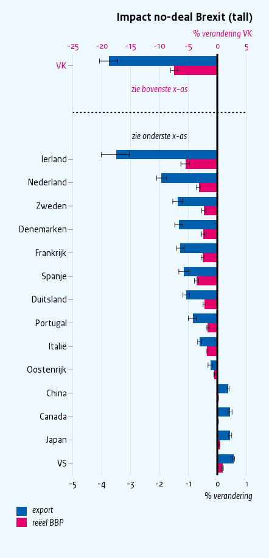

**Relevant parameters:**

| style | tall |
| --- | --- |
| type | bar–, bar–, whisker, whisker, whisker, whisker |
| title | Impact no-deal Brexit (tall) |
| y_title | % verandering |
| y_lab | -5; -4; -3; -2; -1; 0; 1 |
| turn | y |
| x_ticks | 1, 5, 6, 7, 8, 9, 10, 11, 12, 13, 14, 15, 16, 17, 18 |
| y_right_title | % verandering VK |
| y_right_title_col | rose |
| vline_dash | 3 |
| text_x | 2, 4 |
| text_y | -2, -2 |
| text_label | zie bovenste x-as;; zie onderste x-as |
| text_col | rose, black |
| x_lab_col | rose, black, black, black, black, black, black, black, black, black, black, black, black, black, black, black, black, black |
| y_r_lab | -25; -20; -15; -10; -5; 0; 5 |
| y_r_lab_col | rose |
| whisker_legend_show_n | 0 |

**How to reproduce this figure:** copy this xlsx-file and this batch file to a personal directory and start the batch file. You can also run this R-script in R.

The following figure shows the exact same data, without swapping the *x*- and *y*-axis (i.e. `turn = n`). This keeps the countries on the *x*-axis.

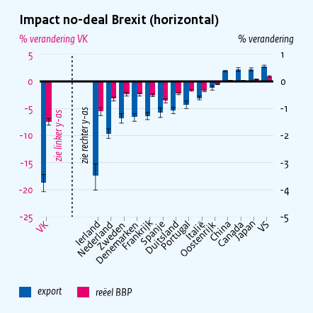

**Relevant parameters:**

| type | bar–, bar–, whisker, whisker, whisker, whisker |
| --- | --- |
| title | Impact no-deal Brexit (horizontal) |
| y_title | % verandering VK |
| y_title_col | rose |
| y_lab | -25; -20; -15; -10; -5; 0; 5 |
| y_lab_col | rose |
| x_ticks | 1, 5, 6, 7, 8, 9, 10, 11, 12, 13, 14, 15, 16, 17, 18 |
| y_right_title | % verandering |
| x_lab_rotation | 45 |
| y_at | -5, -4, -3, -2, -1, 0, 1 |
| vline_dash | 3 |
| text_x | 2, 4 |
| text_y | -2, -2 |
| text_label | zie linker y-as;; zie rechter y-as |
| text_rotation | 90 |
| text_col | rose, black |
| x_lab_col | rose, black, black, black, black, black, black, black, black, black, black, black, black, black, black, black, black, black |
| y_r_lab | -5; -4; -3; -2; -1; 0; 1 |
| legend_n_per_column | 1 |
| legend_y | 0.5 |
| whisker_legend_show_n | 0 |

**How to reproduce this figure:** copy this xlsx-file and this batch file to a personal directory and start the batch file. You can also run this R-script in R.

## 5.12 Legend

Legend position and content can be tweaked in many ways.

- **`legend_column_space`**: space between columns in legend. The value is of type ‘numeric’. Unit: ‘cm’. For the *default* style the value is `0.375`.
- **`legend_font_style`**: 1 = normal, 2 = bold, 3 = italic, 4 = bold and italic. The value is of type ‘numeric’. Example(s): `1, 2, 3, 4`. For the *default* style the value is `3`.
- **`legend_forecast_show`**: added shaded block with dashed line to legend if forecast_x is set. The value is of type ‘bool’. Example(s): `y, n`. For the *default* style the value is `y`. See also parameter(s): forecast_x.
- **`legend_forecast_text`**: text to indicate forecast in right language. The value is of type ‘string’. For the *default* style the value is `start raming`. For the *english* style the value is `prognosis`.
- **`legend_line_distance`**: space between lines in ledgend. The value is of type ‘numeric’. Unit: ‘cm’. For the *default* style the value is `0.315`.
- **`legend_n_per_column`**: number of time series names per column in legend. The value is of type ‘numeric’. Example(s): `1, 4`. For the *default* style the value is `3`. For the *fan* style the value is `4`. Figure(s) using ‘legend_n_per_column’: Investeringen in Nederland¹ door de zwaarst-eurolanden in 2018 en vice versa, Impact no-deal Brexit (horizontal), VMBO, Verwacht verlies in verschillende scenario’s.
- **`legend_order`**: use this to shuffle order or make selection (example shows only series 1, 3 and 5). The value is a list with elements of the type ‘numeric’ separated by ‘,’. Example(s): `1, 3, 5`. Figure(s) using ‘legend_order’: Buitenlandse obligaties in handen van Nederlanders .
- **`legend_show`**: put at `n` if you don’t want a legend. The value is of type ‘bool’. Example(s): `y, n`. For the *default* style the value is `y`. For the *no-legend* style the value is `n`.
- **`legend_space_symbol_txt`**: space between symbol and text. The value is of type ‘numeric’. Unit: ‘cm’. For the *default* style the value is `0.15`.
- **`legend_symbol_height`**: not documented yet. The value is of type ‘numeric’. Unit: ‘fraction of `legend_line_distance`’. For the *default* style the value is `0.8`. See also parameter(s): legend_line_distance.
- **`legend_symbol_width`**: width of symbol in legend. The value is of type ‘numeric’. Unit: ‘cm’. For the *default* style the value is `0.3`.
- **`legend_x`**: position of left side of legend. The value is of type ‘numeric’. Unit: ‘cm’. Example(s): `0.03`. For the *default* style the value is `0.45`.
- **`legend_y`**: position of top of legend, seen from bottom of figure. The value is of type ‘numeric’. Unit: ‘cm’. Example(s): `0.12`. For the *default* style the value is `1.3`. For the *map* style the value is `1.08`. Figure(s) using ‘legend_y’: VWO, Investeringen in Nederland¹ door de zwaarst-eurolanden in 2018 en vice versa, Impact no-deal Brexit (horizontal).
- **`name`**: names of the individual time series. These overwrite the series names in the headers of the data sheet and thus also in the legend. Beware: use ;; as separator between names. The value is a list with elements of the type ‘string’ separated by ‘;;’. Example(s): `bbp;; inflation;; interest`. Figure(s) using ‘name’: Arbeidsmarktregio’s in 2020 volgens CBS.

## 5.13 Colors

James makes it easy to color your time series by putting nice combinations of colors in a so-called palette. You set the palette with parameter `palette`. The default is `palette = auto`. Please note, `auto` is not a palette. `auto` will be replaced by either `cpb_3` if there are less than four time series or by `cpb` if there are more time series. An alternative is `palette = kansrijk` so that the `kansrijk` colors are used (see below for its colors). Might you run out of colors in one palette, you can easily join different palettes, *e.g.* by `palette = cpb, appletv`, which concatenates these two palettes. Subsection Customization of colors and palettes shows an example that customizes colors. Subsection Parameters to tweak your colors describes the use of `palette` in more detail. Below you’ll find the `appletv` and other carefully composed palettes.

### 5.13.1 Color palettes

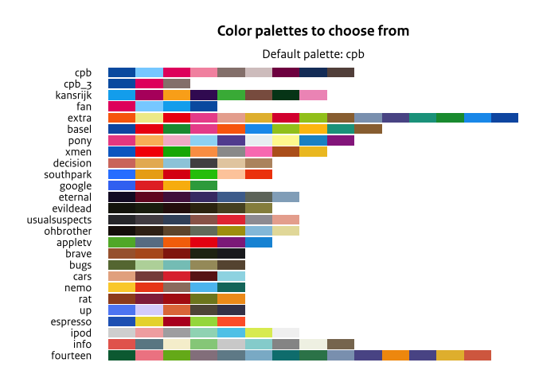

*All except the first four pallets originate from the `yarrr` pacakge. Kudos for the yarrr package!*

#### 5.13.1.1 The default CBP color palette

James gives each color a name. You can admire a specific palette and get the names of its colors as follows in R.

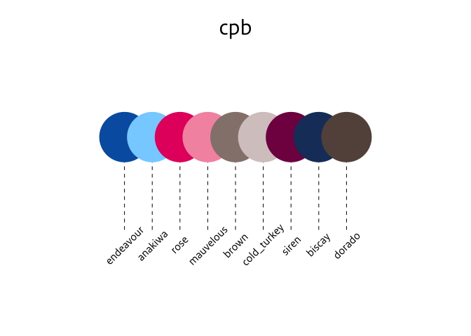

```r
  show_col_pals("cpb", TRUE)
```

#### 5.13.1.2 The kansrijk color palette

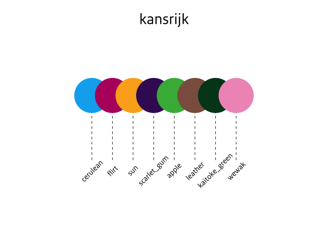

#### 5.13.1.3 The fan color palette

Fan charts are a special case of the bandwidth plots. If `style` is set to `fan`, James will use the below fan palette.

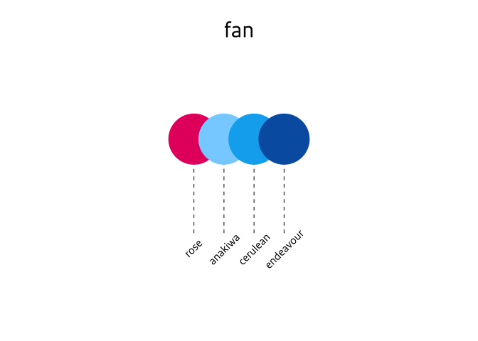

#### 5.13.1.4 Other colors to choose from

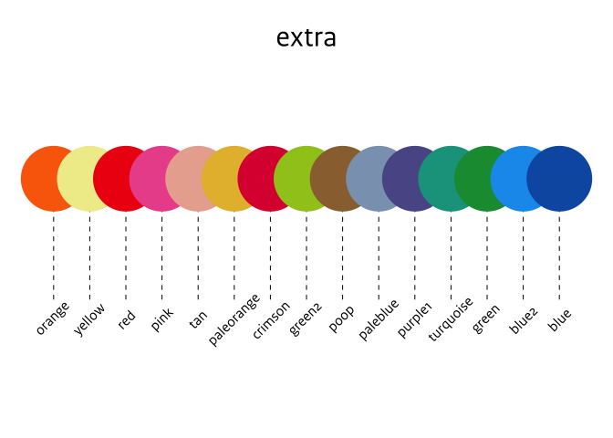

### 5.13.2 Customization of colors and palettes

The use of a color palette makes it straighforward to customize the colors in your figure. You can manually set parameter `palette` to a combination of palettes and separate colors as defined above. The figure below combines three separate colors (red, blue, white) with a palette (appletv).

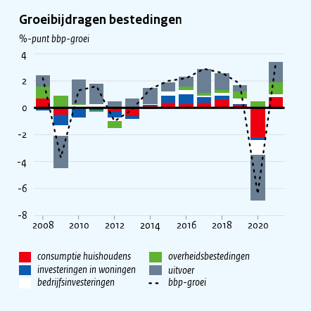

**Relevant parameters:**

| type | bar=, bar=, bar=, bar=, bar=, line |
| --- | --- |
| title | Groeibijdragen bestedingen |
| y_title | %-punt bbp-groei |
| name_col | bbp-groei=black |
| line_lty | 3 |
| palette | red, blue, white, appletv |

**How to reproduce this figure:** copy this xlsx-file and this batch file to a personal directory and start the batch file. You can also run this R-script in R.

### 5.13.3 Parameters to tweak your colors

For colors James uses the [hex triplet](https://en.wikipedia.org/wiki/Web_colors#Hex_triplet) coding. For example, red = #FF0000. You can use both color names for which a color is defined as hex triplets to indicate which colors you want to use.

- **`bg_col`**: background color in your figures. The value is of type ‘string’. For the *default* style the value is `#eef8ff`. For the *kansrijk* style the value is `#ffffff`.
- **`col_order`**: change color order. You may reuse colors as is show in the example. The value is a list with elements of the type ‘numeric’ separated by ‘,’. Example(s): `3, 1, 1, 2, 2`.
- **`color`**: holds the resulting colors in the same order as they are needed during the plotting phase. If you don’t specify its values, the variable will be automatically set during the pre-processing phase based on palette, highlighting, etc. The value is a list with elements of the type ‘string’ separated by ‘,’.
- **`name_col`**: this way you can assign specific colors to specific time series, to ensure each series has one color in different figures. The value is a list with elements of the type ‘string’ separated by ‘;;’. Example(s): `bbp = blue;; inflation = yellow;; interest = pink`. Figure(s) using ‘name_col’: Groeibijdragen bestedingen, Arbeidsmarktregio’s in 2020 volgens CBS.

## 5.14 Data manipulation

You are free to use functions and algebra in your xlsx-file. James will use the result of that. So, if you would put `= 1 + 1` in a cell, Excel will show you the anser (`2`), which will be used by James, too.

Next, there are several ways (*c.q.* parameters) to manipulate your data after you save them in your xlsx-file but before you create the figure:

Data operations, executed in the order of appearance.

- **`order`**: select subset of time series you want to plot. You can also change the order (see example). Please note: the ordering is the very first action (before scaling). It’s the same as re-ordering the columns in your data tab, yourself. The value is a list with elements of the type ‘numeric’ separated by ‘,’. Example(s): `1, 4, 2`.
- **`order_name`**: same as parameter ‘order’ but with time series names instead of numbers. The value is a list with elements of the type ‘string’ separated by ‘;;’. Example(s): `bbp;; inflation;; interest`.
- **`scale`**: scale your data. You may use this for example to scale fractions to percentages (scale = 100). The value is a list with elements of the type ‘numeric’ separated by ‘,’. Example(s): `100`. For the *default* style the value is `1`. Figure(s) using ‘scale’: Buitenlandse obligaties in handen van Nederlanders , kansrijk, Verlies van banken na afschrijving 20% van devan GIIPS-landen.
- **`transformation`**: this transformation function will be applied to each y-value individually. The value is of type ‘string’. Example(s): `log, function(x) x^2`. Figure(s) using ‘transformation’: Werkverliezers.
- **`x_keep`**: remove data outside of this range. Keep data inside range. The example removes all data below 0 and above 100. The value is a list with elements of the type ‘numeric’ separated by ‘,’. Example(s): `0, 100`.
- **`x_scale`**: scales the x-axis. The value is of type ‘numeric’. Example(s): `0.001, 100`. For the *default* style the value is `1`. Figure(s) using ‘x_scale’: Decompositie gemiddelde marginale belastingdruk werknemers 2021 .
- **`y_keep`**: see x_keep. The value is a list with elements of the type ‘numeric’ separated by ‘,’.

> Please note that the data manipulations are performed in the above order.

The most straightforward one is `order`, which you can use to re-order your columns before anything else happens. For example, if you would have a data set with only two time series, `order = 2, 1` will have the same effect as swapping the corresponding two columns in the xlsx-file.

The second step in the data manipulation phase is the scaling of your data. For example, `scale = 100` may be used to convert fractions into percentages. If you supply only one value here, that value will be applied to each series. However, you may also choose to scale different series with different values. For example, if you have two time series and `scale = 100, 1`, only the first one will be multiplied by 100.

Similarly to scaling your *y*-values, with `x_scale` you can scale the values on your *x*-axis. Please see this figure for an example.

The third and last step in the data manipulation phase is a transformation with custom R-code. You can put your own custom transformation function there, but you can also use R’s built-in-functions such as `log` in the next figure. Please note that data are first scaled and then transformed.

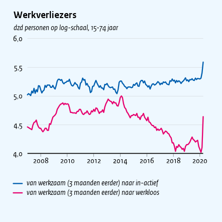

**Relevant parameters:**

| title | Werkverliezers |
| --- | --- |
| y_title | dzd personen op log-schaal, 15-74 jaar |
| x_lim_follow_data | y |
| transformation | log |

**How to reproduce this figure:** copy this xlsx-file and this batch file to a personal directory and start the batch file. You can also run this R-script in R.

The parameter `x_lim_follow_data = y` (see `x_lim_follow_data`) makes the x-axis zoom-in to the max so you don’t have white spaces left and right. This parameter will be discussed in more detail in the Section about axes.

## 5.15 Structure of the xlsx-file

James only processes xlsx files that have a tab called `meta`. Other files, *i.e.* *.xls,* .csv files, or xlsx files that don’t have a `meta` tab, are ignored.

### 5.15.1 The meta tab

The `meta` tab defines your figures. The first column contains the parameters (*e.g.* for a title). Each following column defines a different figure with parameter values specific for that figure. An example of a frequently used parameter is:

- **`tab`**: tab-name of the tab holding the data for the figure. You may refer more than once to the same tab, *e.g.* if you want to make figures in different languages. The value is of type ‘string’. Figure(s) using ‘tab’: Hello World, Werkloosheid, Ontwikkeling EMU-schuld in schokscenario’s, Six different line types, Industriële productie en detailhandel, Buitenlandse obligaties in handen van Nederlanders , Two bandwiths in one plot, Oversterfte in 2020, Inflatie, Inkomenseffecten plannen- en belastingstelsel, Kans om in risicogroep te zitten, kansrijk, Bestaande koopwoningen, Werkverliezers, A discontinuity, Europese steunpakketten, Decompositie gemiddelde marginale belastingdruk werknemers 2021 , VWO, VWO, VWO, Investeringen in Nederland¹ door de zwaarst-eurolanden in 2018 en vice versa, Groeibijdragen bestedingen, geo-first-example, Arbeidsmarktregio’s in 2020 volgens CBS, Koopkrachtontwikkeling, Koopkrachtontwikkeling, Verlies van banken na afschrijving 20% van devan GIIPS-landen, Industriële productie en detailhandel, Toeslagen, Rentespreads op overheidsschuld, Overlapping labels (NL, PT), Different alignment for PT, trend-vs-niveau, Impact no-deal Brexit (horizontal), Impact no-deal Brexit (tall), VMBO, Verwacht verlies in verschillende scenario’s, Verwacht verlies in verschillende scenario’s, Economische groei in Nederland.

### 5.15.2 The globals tab

You may add a tab called `global`. Parameters defined in this tab are assigned to each of the figures in the `meta` tab, unless overwritten there.

### 5.15.3 The data tabs

There are two different ways to refer to a data set for your figure. One of them is via the parameter `tab` in your `meta` tab. The other way is to refer to a data set via a `CBS link` (discussed in the next subsection). The value of the parameter `tab` should equal the name of one of the tabs in your xlsx file and hold your data. Such a ‘data tab’ can have different forms. The most straightforward form is *x*-values in the first column, and time series in the following columns. Each time series should have a header (*i.e.* a name) defined in the first row of the tab.

#### 5.15.3.1 The x-column may also be text

In case of bar plot.

#### 5.15.3.2 Grouping time series

James assumes that the first row in the data tab contains the time series names. If, however, the second row contains characters (*i.e.* not all are numbers), however, James assumes you want to group the series. Please note: you can force the grouping with parameter `first_row_grouping = y` (see: `first_row_grouping`) or disable it with `first_row_grouping = n`. Below you’ll find examples of the grouping.

#### 5.15.3.3 Defining a parameter in a data tab

TODO Explain how that works. Section Text label illustrates an example.

# 6 Plot CBS-data in the CBP-style, using only a link

In some cases, James can plot data straight from a cbs url. Don’t use the url in the url-bar for that, but click on the ‘export’ or ‘share’ button to find the data url, which you can feed to James.

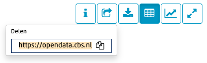

In this case, the author has constructed a table with sold house prices in The Netherlands and in ’s-Gravenhage, a municipality.

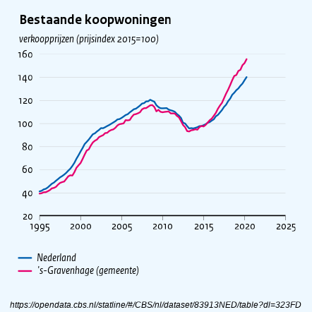

This way, your figure is always up-to-date at the moment you create it.

**Relevant parameters:**

| cbs_url | https://opendata.cbs.nl/statline/#/CBS/nl/dataset/83913NED/table?dl=323FD |
| --- | --- |
| title | Bestaande koopwoningen |
| y_title | verkoopprijzen (prijsindex 2015=100) |
| footnote | https://opendata.cbs.nl/statline/#/CBS/nl/dataset/83913NED/table?dl=323FD |
| tab | NA |

**How to reproduce this figure:** copy this xlsx-file and this batch file to a personal directory and start the batch file. You can also run this R-script in R.

It may very well be that this functionality does not work in your case. Please contact the author if you don’t succeed.

## 6.1 Adding your own data to CBS-data

If you refer both to a CBS-url and to a data tab, James will combine the two data sets. For example:

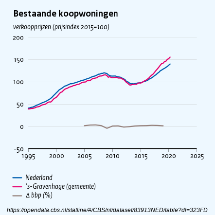

**Relevant parameters:**

| cbs_url | https://opendata.cbs.nl/statline/#/CBS/nl/dataset/83913NED/table?dl=323FD |
| --- | --- |
| title | Bestaande koopwoningen |
| y_title | verkoopprijzen (prijsindex 2015=100) |
| footnote | https://opendata.cbs.nl/statline/#/CBS/nl/dataset/83913NED/table?dl=323FD |
| order | 2, 3, 1 |

**How to reproduce this figure:** copy this xlsx-file and this batch file to a personal directory and start the batch file. You can also run this R-script in R.

James puts your own data set first. To make this figure best comparable to the previous, we’ve changed the order of the time series with parameter `order = 2, 3, 1` so the added bbp series comes third. More about the parameter `order` in Section ‘Data manipulation’.

In this case, the added data (‘$\Delta$bbp (%)’) has a different unit and should be shown on another *y*-axis. The section on how to customize your axes explains in detail how to do so.

# 7 Create a report

James can put your figures in a report, which enables you to have a quick overview and easily share them with colleagues. Next to your figures, you can add a new column and set `type = report` there. That’s all.

## 7.1 A kick-start example

Report with only one fig.

## 7.2 Title, author, date and adding a figure

## 7.3 A realistic report

This report is what you get out-of-the-box if you run this xlsx-file (*cf.* [‘kMEV2021’ or ‘juniraming 2020’](https://www.cpb.nl/sites/default/files/omnidownload/CPB-Juniraming-2020.pdf)).

## 7.4 Customize the report’s text

## 7.5 Parameters to tweak your report

- **`author`**: put here the author if you don’t want to use the default. The value is of type ‘string’. Example(s): `"`r whoami::fullname()`"`.
- **`date`**: what you want as date. You may use the example if you want today’s date. The value is of type ‘string’. Example(s): `"`r format(Sys.Date())`"`.
- **`pandoc_location_windows`**: not documented yet. The value is of type ‘file’. For the *default* style the value is `S:/Applicaties/CPB/pandoc`.
- **`report_default_data_show`**: not documented yet. The value is of type ‘bool’. For the *default* style the value is `n`.
- **`report_default_fig_show`**: not documented yet. The value is of type ‘bool’. For the *default* style the value is `y`.
- **`report_default_file`**: not documented yet. The value is of type ‘path’. For the *default* style the value is `ext/snippet/james-report-default.Rmd`.
- **`report_default_param_show`**: not documented yet. The value is of type ‘bool’. For the *default* style the value is `n`.
- **`report_dir`**: not documented yet. The value is of type ‘path’. For the *default* style the value is `report`.
- **`report_format`**: not documented yet. The value is a list with elements of the type ‘string’ separated by ‘,’. Example(s): `html, pdf, word, ioslides, slidy, beamer, powerpoint`. For the *default* style the value is `html`.
- **`report_include_james_appendix`**: not documented yet. The value is of type ‘bool’. For the *default* style the value is `y`. Figure(s) using ‘report_include_james_appendix’: report.
- **`report_james_appendix_path`**: not documented yet. The value is of type ‘path’. For the *default* style the value is `ext/snippet/james-appendix.Rmd`.
- **`report_show`**: specify what you want in the header of your report. Please choose at least one. The value is a list with elements of the type ‘string’ separated by ‘,’. For the *default* style the value is `title, author, date`.
- **`report_table_of_content`**: not documented yet. The value is of type ‘bool’. For the *default* style the value is `y`.
- **`report_text`**: you can put your report (R-markdown) text here directly. If you need more space, you can put your text in a sheet and refer to that sheet with parameter `tab`. The last option is to put your text in a separate file using parameter `report_text_file`. The value is of type ‘string’. See also parameter(s): tab, report_text_file.
- **`report_text_file`**: path to the Rmd-file in which you have put the custom r-markdown text for your report (with or without yaml-header). The value is of type ‘file’. Figure(s) using ‘report_text_file’: report.
- **`report_yaml_custom`**: add custom yaml (injected at end). The value is of type ‘string’.
- **`report_yaml_default`**: not documented yet. The value is of type ‘path’. For the *default* style the value is `ext/snippet/yaml-default.Rmd`.
- **`report_yaml_html`**: not documented yet. The value is of type ‘path’. For the *default* style the value is `ext/snippet/yaml-html.Rmd`.
- **`report_yaml_ioslides`**: not documented yet. The value is of type ‘path’. For the *default* style the value is `ext/snippet/yaml-ioslides.Rmd`.
- **`report_yaml_pdf`**: not documented yet. The value is of type ‘path’. For the *default* style the value is `ext/snippet/yaml-pdf.Rmd`.
- **`report_yaml_powerpoint`**: not documented yet. The value is of type ‘path’. For the *default* style the value is `ext/snippet/yaml-powerpoint.Rmd`.
- **`report_yaml_toc`**: not documented yet. The value is of type ‘path’. For the *default* style the value is `ext/snippet/yaml-toc.Rmd`.
- **`report_yaml_word`**: not documented yet. The value is of type ‘path’. For the *default* style the value is `ext/snippet/yaml-word.Rmd`.

# 8 Under the hood

Building the manual involves creating its figures too. Therefore, the building of the manual is a comprehensive test by itself.

The value of a James-parameter may depend on the style(s) you set. You can find these parameter/style combinations in `M:/p_james/dev/dev-2020-10-21/ext/james-base-settings.xlsx` (available as variable `globals` if you run the R-code). You can overwrite a parameter value in both the `globals` tab and the `meta` tab of your Excel file.

Based on the parameters, James creates the figures as follows. First a series of pre-processing functions are executed. You can easily add new functions (see parameter `preprocess_order`) and/or override these functions: (1) `add_style`, (2) `preprocess_data_grouping_variables`, (3) `validate`, (4) `append_formula`, (5) `data_operations`, (6) `preprocess_first`, (7) `replicate_params`, (8) `forecast_pre`, (9) `label_pre`, (10) `area_stack_pre`, (11) `bars_pre`, (12) `whisker_pre`, (13) `box_pre`, (14) `dot_pre`, (15) `linez_pre`, (16) `area_pre`, (17) `color_pre`, (18) `legend_pre`, (19) `set_lims`, (20) `set_labs`, (21) `find_y_r_scaling`, (22) `logo_pre`, (23) `set_file_name`.

Next, the process functions are executed (see parameter `plot_order`): (1) `format_labs_set_margin_west`, (2) `set_layout_and_init_plot`, (3) `set_line_distance`, (4) `forecast_bg`, (5) `shading`, (6) `rectangle`, (7) `axes`, (8) `gridlines`, (9) `area_stack`, (10) `area`, (11) `bars`, (12) `jbox`, (13) `dot`, (14) `linez`, (15) `whisker`, (16) `label`, (17) `shading_suppress`, (18) `custom`, (19) `bold_axis`, (20) `user_line`, (21) `text_label`, (22) `forecast`, (23) `margins_0000`, (24) `j_legend`, (25) `titles`, (26) `footnote`, (27) `logo`.

If you want to further improve or extend James, you can update these functions by overriding them in R or add novel functionlity in an R script and adapting the `preprocess_order` and `plot_order` lists accordingly.

Note to the developer: you can use `get_param_settings_not_in_any_R_file()` to get a list of parameters that are defined, but seem not used in any R-script nor code snippet.

## 8.1 Structure of the software

Please find

- a copy of this manual: `M:/p_james/dev/dev-2020-10-21/*.html`
- a batch, sh and R-script to start James in `M:/p_james/dev/dev-2020-10-21/`
- examples for this manual (xlsx) in `M:/p_james/dev/dev-2020-10-21/examples/xlsx`
  - with 0 files total
- examples for this manual (R) in `M:/p_james/dev/dev-2020-10-21/examples/R`
  - with 0 files total
- R-code in `M:/p_james/dev/dev-2020-10-21/R/`
  - with 0 files total
- images in `M:/p_james/dev/dev-2020-10-21/ext/img/`
  - with 0 files total
- mapping user names, full names in `M:/p_james/dev/dev-2020-10-21/ext/misc/`
  - with 0 files total
- report examples, including this manual `M:/p_james/dev/dev-2020-10-21/ext/report/`
  - with 0 files total
- code snippets including templates to generate scripts in `M:/p_james/dev/dev-2020-10-21/ext/snippet/`
  - with 0 files total
- markup files in `M:/p_james/dev/dev-2020-10-21/ext/style/`
  - with 0 files total

## 8.2 Stats for nerds

James (version `dev-2020-10-21`) built this manual at 2020-10-21 12:49:50. This took 2.6 seconds. The current version of James counts 452 parameters.

# 9 Feature requests and future development

Please add your feature requests or bug report here: https://tinyurl.com/james-feature-request, so it’s easy to

- [x] mark what has been done
- [ ] prioritize tasks
- [ ] contact you

# 10 Troubleshooting

In general, the advice is to work in small steps; *e.g.* changing one or two parameters at a time. This helps to isolate a potential problem. However, if you think you’ve found a bug, you indeed most likely did so. In which case, please first check whether there is a new version available in M:/p_james/dev. If not, then please put a copy of your xlsx-file in `M:/p_jamesgebruiker/q/$usr$` (please replace `$usr$` with your own user name) and e-mail your bug report to m.dijkstra@cpb.nl. Thanks!

# 11 Acknowledgements

## 11.1 On the origin of James

On April 19, 2017, our King, Willem Alexander van Oranje-Nassau, officially opened our new building B30. That day, prof.dr. Bas Haring was one of the invited speaker. He encouraged us to present our results in terms of stories/parables. His idea inspired the author to frame the discussed software as a person called ‘James’. A personal servant ‘James’ for each of our colleagues!

## 11.2 Kudos to all of you

Meinou de Vries created James’ logo. Many early users exposed bugs in the software. Kudos to all of you!

# 12 Appendix

## 12.1 CBS Geo-regions

This section lists all geo-regions you can choose from:

*arbeidsmarktregio_2014, arbeidsmarktregio_2015, arbeidsmarktregio_2016, arbeidsmarktregio_2017, arbeidsmarktregio_2018, arbeidsmarktregio_2019, arbeidsmarktregio_2020, arrondissementsgebied_1995, arrondissementsgebied_1996, arrondissementsgebied_1997, arrondissementsgebied_1998, arrondissementsgebied_1999, arrondissementsgebied_2000, arrondissementsgebied_2001, arrondissementsgebied_2002, arrondissementsgebied_2003, arrondissementsgebied_2004, arrondissementsgebied_2005, arrondissementsgebied_2006, arrondissementsgebied_2007, arrondissementsgebied_2008, arrondissementsgebied_2009, arrondissementsgebied_2010, arrondissementsgebied_2011, arrondissementsgebied_2012, arrondissementsgebied_2013, arrondissementsgebied_2014, arrondissementsgebied_2015, arrondissementsgebied_2016, arrondissementsgebied_2017, arrondissementsgebied_2018, arrondissementsgebied_2019, arrondissementsgebied_2020, brandweerregio_1995, brandweerregio_1996, brandweerregio_1997, brandweerregio_1998, brandweerregio_1999, brandweerregio_2000, brandweerregio_2001, brandweerregio_2002, brandweerregio_2003, brandweerregio_2004, brandweerregio_2005, brandweerregio_2006, brandweerregio_2007, brandweerregio_2008, brandweerregio_2009, brandweerregio_2010, buurt_1995, buurt_1996, buurt_1997, buurt_1998, buurt_1999, buurt_2000, buurt_2001, buurt_2002, buurt_2003, buurt_2004, buurt_2005, buurt_2006, buurt_2007, buurt_2008, buurt_2009, buurt_2010, buurt_2011, buurt_2012, buurt_2013, buurt_2014, buurt_2015, buurt_2016, buurt_2017, buurt_2018, buurt_2019, buurt_2019_niet, buurt_2020, buurt_2020_niet, coropgebied_1995, coropgebied_1996, coropgebied_1997, coropgebied_1998, coropgebied_1999, coropgebied_2000, coropgebied_2001, coropgebied_2002, coropgebied_2003, coropgebied_2004, coropgebied_2005, coropgebied_2006, coropgebied_2007, coropgebied_2008, coropgebied_2009, coropgebied_2010, coropgebied_2011, coropgebied_2012, coropgebied_2013, coropgebied_2014, coropgebied_2015, coropgebied_2016, coropgebied_2017, coropgebied_2018, coropgebied_2019, coropgebied_2020, coropplusgebied_2005, coropplusgebied_2006, coropplusgebied_2007, coropplusgebied_2008, coropplusgebied_2009, coropplusgebied_2010, coropplusgebied_2011, coropplusgebied_2012, coropplusgebied_2013, coropplusgebied_2014, coropplusgebied_2015, coropplusgebied_2016, coropplusgebied_2017, coropplusgebied_2018, coropplusgebied_2019, coropplusgebied_2020, coropsubgebied_1995, coropsubgebied_1996, coropsubgebied_1997, coropsubgebied_1998, coropsubgebied_1999, coropsubgebied_2000, coropsubgebied_2001, coropsubgebied_2002, coropsubgebied_2003, coropsubgebied_2004, coropsubgebied_2005, coropsubgebied_2006, coropsubgebied_2007, coropsubgebied_2008, coropsubgebied_2009, coropsubgebied_2010, coropsubgebied_2011, coropsubgebied_2012, coropsubgebied_2013, coropsubgebied_2014, coropsubgebied_2015, coropsubgebied_2016, coropsubgebied_2017, coropsubgebied_2018, coropsubgebied_2019, coropsubgebied_2020, gemeente_1995, gemeente_1996, gemeente_1997, gemeente_1998, gemeente_1999, gemeente_2000, gemeente_2001, gemeente_2002, gemeente_2003, gemeente_2004, gemeente_2005, gemeente_2006, gemeente_2007, gemeente_2008, gemeente_2009, gemeente_2010, gemeente_2011, gemeente_2012, gemeente_2013, gemeente_2014, gemeente_2015, gemeente_2016, gemeente_2017, gemeente_2018, gemeente_2019, gemeente_2019_niet, gemeente_2020, gemeente_2020_niet, ggdregio_1995, ggdregio_1996, ggdregio_1997, ggdregio_1998, ggdregio_1999, ggdregio_2000, ggdregio_2001, ggdregio_2003, ggdregio_2004, ggdregio_2005, ggdregio_2006, ggdregio_2007, ggdregio_2008, ggdregio_2009, ggdregio_2010, ggdregio_2011, ggdregio_2012, ggdregio_2013, ggdregio_2014, ggdregio_2015, ggdregio_2016, ggdregio_2017, ggdregio_2018, ggdregio_2019, ggdregio_2020, grootstedelijke_agglomeratie_2000, grootstedelijke_agglomeratie_2001, grootstedelijke_agglomeratie_2002, grootstedelijke_agglomeratie_2003, grootstedelijke_agglomeratie_2004, grootstedelijke_agglomeratie_2005, grootstedelijke_agglomeratie_2006, grootstedelijke_agglomeratie_2007, grootstedelijke_agglomeratie_2008, grootstedelijke_agglomeratie_2009, grootstedelijke_agglomeratie_2010, grootstedelijke_agglomeratie_2011, grootstedelijke_agglomeratie_2012, grootstedelijke_agglomeratie_2013, grootstedelijke_agglomeratie_2014, grootstedelijke_agglomeratie_2015, jeugdregio_2015, jeugdregio_2016, jeugdregio_2017, jeugdregio_2018, jeugdregio_2019, jeugdregio_2020, kamervankoophandelregio_2008, kamervankoophandelregio_2009, kamervankoophandelregio_2010, kamervankoophandelregio_2011, kamervankoophandelregio_2012, kamervankoophandelregio_2013, kamervankoophandelregio_2014, kamervankoophandelregio_2015, kamervankoophandelregio_2016, kamervankoophandelregio_2017, kamervankoophandelregio_2018, kamervankoophandelregio_2019, kamervankoophandelregio_2020, landbouwgebied_1995, landbouwgebied_1996, landbouwgebied_1997, landbouwgebied_1998, landbouwgebied_1999, landbouwgebied_2000, landbouwgebied_2001, landbouwgebied_2002, landbouwgebied_2003, landbouwgebied_2004, landbouwgebied_2005, landbouwgebied_2006, landbouwgebied_2007, landbouwgebied_2008, landbouwgebied_2009, landbouwgebied_2010, landbouwgebied_2011, landbouwgebied_2012, landbouwgebied_2013, landbouwgebied_2014, landbouwgebied_2015, landbouwgebied_2016, landbouwgebied_2017, landbouwgebied_2018, landbouwgebied_2019, landbouwgebied_2020, landbouwgroep_1995, landbouwgroep_1996, landbouwgroep_1997, landbouwgroep_1998, landbouwgroep_1999, landbouwgroep_2000, landbouwgroep_2001, landbouwgroep_2002, landbouwgroep_2003, landbouwgroep_2004, landbouwgroep_2005, landbouwgroep_2006, landbouwgroep_2007, landbouwgroep_2008, landbouwgroep_2009, landbouwgroep_2010, landbouwgroep_2011, landbouwgroep_2012, landbouwgroep_2013, landbouwgroep_2014, landbouwgroep_2015, landbouwgroep_2016, landbouwgroep_2017, landbouwgroep_2018, landbouwgroep_2019, landbouwgroep_2020, landsdeel_1995, landsdeel_1996, landsdeel_1997, landsdeel_1998, landsdeel_1999, landsdeel_2000, landsdeel_2001, landsdeel_2002, landsdeel_2003, landsdeel_2004, landsdeel_2005, landsdeel_2006, landsdeel_2007, landsdeel_2008, landsdeel_2009, landsdeel_2010, landsdeel_2011, landsdeel_2012, landsdeel_2013, landsdeel_2014, landsdeel_2015, landsdeel_2016, landsdeel_2017, landsdeel_2018, landsdeel_2019, landsdeel_2020, nuts1_2003, nuts1_2006, nuts1_2010, nuts1_2013, nuts1_2016, nuts2_2003, nuts2_2006, nuts2_2010, nuts2_2013, nuts2_2016, nuts3_2003, nuts3_2006, nuts3_2010, nuts3_2013, nuts3_2016, politieregio_1995, politieregio_1996, politieregio_1997, politieregio_1998, politieregio_1999, politieregio_2000, politieregio_2001, politieregio_2002, politieregio_2003, politieregio_2004, politieregio_2005, politieregio_2006, politieregio_2007, politieregio_2008, politieregio_2009, politieregio_2010, politieregio_2011, politieregio_2012, politieregio_2013, provincie_1995, provincie_1996, provincie_1997, provincie_1998, provincie_1999, provincie_2000, provincie_2001, provincie_2002, provincie_2003, provincie_2004, provincie_2005, provincie_2006, provincie_2007, provincie_2008, provincie_2009, provincie_2010, provincie_2011, provincie_2012, provincie_2013, provincie_2014, provincie_2015, provincie_2016, provincie_2017, provincie_2018, provincie_2019, provincie_2020, regionaalmeld_coordinatiepunt_2017, regionaalmeld_coordinatiepunt_2018, regionaalmeld_coordinatiepunt_2019, regionaalmeld_coordinatiepunt_2020, regionale_eenheid_2014, regionale_eenheid_2015, regionale_eenheid_2016, regionale_eenheid_2017, regionale_eenheid_2018, regionale_eenheid_2019, regionale_eenheid_2020, regionale_energiestrategie_2018, regionale_energiestrategie_2019, regionale_energiestrategie_2020, regioplus_arbeidsmarktregio_2015, regioplus_arbeidsmarktregio_2016, regioplus_arbeidsmarktregio_2017, regioplus_arbeidsmarktregio_2018, regioplus_arbeidsmarktregio_2019, regioplus_arbeidsmarktregio_2020, ressort_2015, ressort_2016, ressort_2017, ressort_2018, ressort_2019, ressort_2020, rpagebied_2002, rpagebied_2003, rpagebied_2004, rpagebied_2005, rpagebied_2006, rpagebied_2007, rpagebied_2008, rpagebied_2009, rpagebied_2010, rpagebied_2011, rpagebied_2012, rpagebied_2013, rpagebied_2014, rpagebied_2015, rpagebied_2016, stadsgewest_2000, stadsgewest_2001, stadsgewest_2002, stadsgewest_2003, stadsgewest_2004, stadsgewest_2005, stadsgewest_2006, stadsgewest_2007, stadsgewest_2008, stadsgewest_2009, stadsgewest_2010, stadsgewest_2011, stadsgewest_2012, stadsgewest_2013, stadsgewest_2014, stadsgewest_2015, toeristengebied_1995, toeristengebied_1996, toeristengebied_1997, toeristengebied_1998, toeristengebied_1999, toeristengebied_2000, toeristengebied_2001, toeristengebied_2002, toeristengebied_2003, toeristengebied_2004, toeristengebied_2005, toeristengebied_2006, toeristengebied_2007, toeristengebied_2008, toeristengebied_2009, toeristengebied_2010, toeristengebied_2011, toeristengebied_2012, toeristengebied_2013, toeristengebied_2014, toeristengebied_2015, toeristengebied_2016, toeristengebied_2017, toeristengebied_2018, toeristengebied_2019, toeristengebied_2020, toeristengroep_2006, toeristengroep_2009, toeristengroep_2010, toeristengroep_2011, toeristengroep_2014, toeristengroep_2015, toeristengroep_2016, toeristengroep_2017, toeristengroep_2018, toeristengroep_2019, toeristengroep_2020, veiligheidsregio_2011, veiligheidsregio_2012, veiligheidsregio_2013, veiligheidsregio_2014, veiligheidsregio_2015, veiligheidsregio_2016, veiligheidsregio_2017, veiligheidsregio_2018, veiligheidsregio_2019, veiligheidsregio_2020, veiligthuisregio_2020, wijk_1995, wijk_1996, wijk_1997, wijk_1998, wijk_1999, wijk_2000, wijk_2001, wijk_2002, wijk_2003, wijk_2004, wijk_2005, wijk_2006, wijk_2007, wijk_2008, wijk_2009, wijk_2010, wijk_2011, wijk_2012, wijk_2013, wijk_2014, wijk_2015, wijk_2016, wijk_2017, wijk_2018, wijk_2019, wijk_2019_niet, wijk_2020, wijk_2020_niet, zorgkantoorregio_2009, zorgkantoorregio_2010, zorgkantoorregio_2011, zorgkantoorregio_2012, zorgkantoorregio_2013, zorgkantoorregio_2014, zorgkantoorregio_2015, zorgkantoorregio_2016, zorgkantoorregio_2017, zorgkantoorregio_2018, zorgkantoorregio_2019, zorgkantoorregio_2020*.

## 12.2 List of all parameters available to the user

This section lists all parameters, which are available to the user, in alphabetical order. Many of these parameters are already documented in the manual above. If you want to make use of a parameter that is documented poorly (sorry for that), please contact the author.